# Reproducible Research: Peer Assessment 1

Loading and preprocessing the data 1. Load the data (i.e. read.csv()) 2. Process/transform the data (if necessary) into a format suitable for your analysis

```r
data <- read.csv("activity.csv",header=TRUE)
```

What is mean total number of steps taken per day? 1. Calculate the total number of steps taken per day

```r
date <- levels(data$date)
n = 1;
total = 0;
newdata <- data.frame(Date=vector(), TotalSteps=numeric())
for (i in 1:nrow(data)) {
  if (as.vector(data[i,2]) == date[n])
        total = total + data[i,1]
         else {
                newdata[n,1] <- date[n]
                newdata[n,2] <- total
                n = n+1
                total = 0
                }
}
newdata[n,2] = total;
newdata[n,1] = date[n]
#plot(as.Date(newdata$Date), newdata$TotalSteps)
```

2. Make a histogram of the total number of steps taken each day

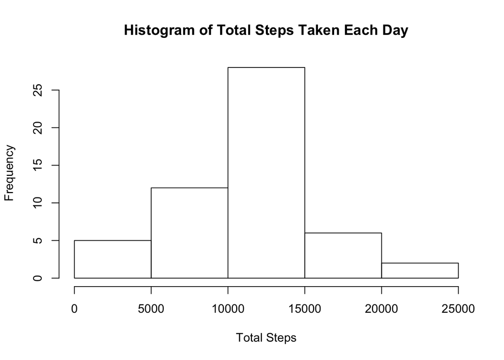

```r
with(newdata,hist(newdata$TotalSteps,xla='Total Steps',main='Histogram of Total Steps Taken Each Day'))
```

3. Calculate and report the mean and median of the total number of steps taken per day

```r
mean(newdata$TotalSteps,na.rm=TRUE)
```

```
## [1] 10764.47
```

```r
median(newdata$TotalSteps,na.rm=TRUE)
```

```
## [1] 10765
```

What is the average daily activity pattern?

1. Make a time series plot (i.e. type = “l”) of the 5-minute interval (x-axis) and the average number of steps taken, averaged across all days (y-axis)

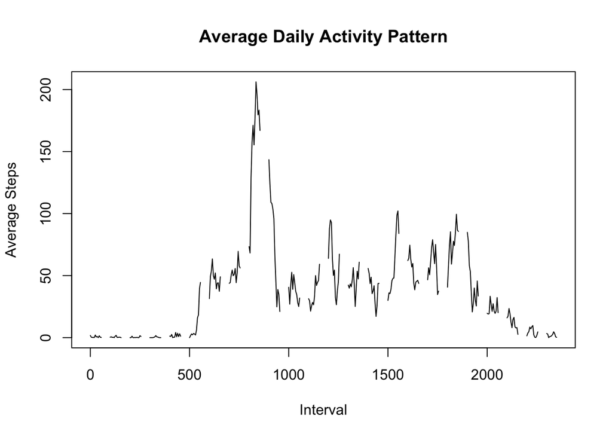

```r
newdata2 <- data.frame(Interval=numeric(), AverageSteps=numeric())
for (i in 1:round(max(data$interval)/5)) {
        total <- data.frame(Total=numeric())
        newdata2[i,1] <- (i-1)*5
        n = 1
        for (j in 1:length(data$interval)) {
                if (data$interval[j] == newdata2[i,1]) {
                        total[n,1] <- data[j,1]
                        n = n+1
                }
        }
        newdata2[i,2] <- mean(total[,1],na.rm=TRUE)
}
with(newdata2,plot(Interval,AverageSteps,type='l',xlab='Interval',ylab='Average Steps',main='Average Daily Activity Pattern'))
```

2. Which 5-minute interval, on average across all the days in the dataset, contains the maximum number of steps?

```r
n=1
target <- data.frame()
maxvalue <- max(newdata2$AverageSteps,na.rm=TRUE)
for (i in 1:length(newdata2$Interval)){
        if (!is.na(newdata2[i,2]) & (newdata2[i,2] == maxvalue)) {
                target[n,1] = newdata2[i,1]
                n=n+1
        }
}
colnames(target) <- "Interval"
target
```

```
##   Interval
## 1      835
```

Imputing missing values 1. Calculate and report the total number of missing values in the dataset (i.e. the total number of rows with NAs)

```r
num = 0
for (i in 1:length(data$steps)) {
        if (is.na(data[i,1])==TRUE)  num = num+1
}
num
```

```
## [1] 2304
```

Create a new dataset that is equal to the original dataset but with the missing data filled in. The mean for the specific 5-minute interval is used for filling the missing data

```r
filldata <- data
for (i in 1:length(filldata$steps)) {
        if (is.na(filldata[i,1])==TRUE) {
                for (j in 1:length(newdata2$Interval)) {
                        if (filldata[i,3]==newdata2[j,1])
                        filldata[i,1] = newdata2[j,2]
                }
        }
}
head(filldata)
```

```
##       steps       date interval
## 1 1.7169811 2012-10-01        0
## 2 0.3396226 2012-10-01        5
## 3 0.1320755 2012-10-01       10
## 4 0.1509434 2012-10-01       15
## 5 0.0754717 2012-10-01       20
## 6 2.0943396 2012-10-01       25
```

Make a histogram of the total number of steps taken each day and Calculate and report the mean and median total number of steps taken per day.

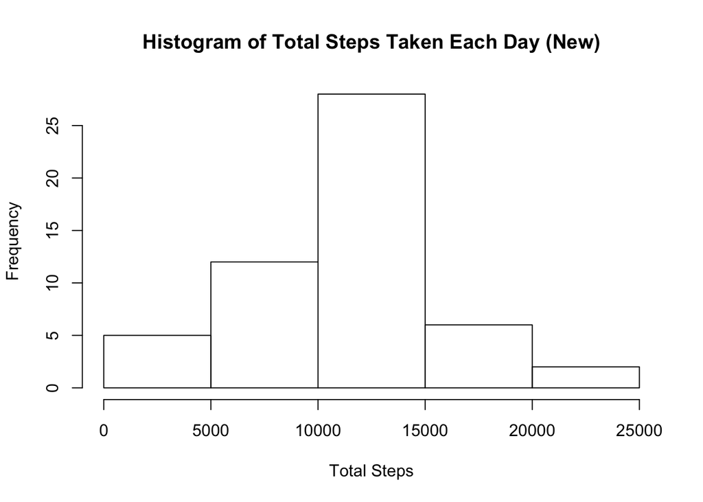

```r
n = 1
total = 0
newfilldata <- data.frame(Date=vector(), TotalSteps=numeric())
for (i in 1:nrow(filldata)) {
        if (as.vector(filldata[i,2]) == date[n])
                total = total + filldata[i,1]
        else {
                newfilldata[n,1] <- date[n]
                newfilldata[n,2] <- total
                n = n+1
                total = 0
        }
}
newfilldata[n,2] = total;
newfilldata[n,1] = date[n]
with(newfilldata,hist(newfilldata$TotalSteps,xla='Total Steps',main='Histogram of Total Steps Taken Each Day (New)'))
```

```r
mean(newfilldata$TotalSteps,na.rm=TRUE)
```

```
## [1] 10764.47
```

```r
median(newfilldata$TotalSteps,na.rm=TRUE)
```

```
## [1] 10765
```

```r
filldata[,4] <- c()
for (i in 1:length(filldata$date)) {
        filldata[i,4] = weekdays(as.Date(filldata[i,2]))
}
colnames(filldata) <- c("steps","date","interval","weekday/weekend")
head(filldata)
```

```
##       steps       date interval weekday/weekend
## 1 1.7169811 2012-10-01        0          Monday
## 2 0.3396226 2012-10-01        5          Monday
## 3 0.1320755 2012-10-01       10          Monday
## 4 0.1509434 2012-10-01       15          Monday
## 5 0.0754717 2012-10-01       20          Monday
## 6 2.0943396 2012-10-01       25          Monday
```

2. Make a panel plot containing a time series plot (i.e. type = “l”) of the 5-minute interval (x-axis) and the average number of steps taken, averaged across all weekday days or weekend days (y-axis).

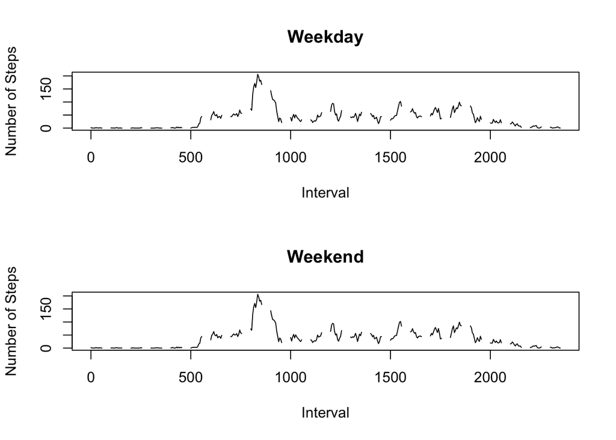

```r
weekday <- data.frame()
weekend <- data.frame()

for (i in 1:length(filldata$date)) {
        if (weekdays(as.Date(filldata[i,2])) == "Saturday" | weekdays(as.Date(filldata[i,2])) == "Sunday")
                weekend <- rbind(weekend,filldata[i,])
                else weekday <- rbind(weekday,filldata[i,])
}

weekdaynew <- data.frame(Interval=numeric(), AverageSteps=numeric())
weekendnew <- data.frame(Interval=numeric(), AverageSteps=numeric())

for (i in 1:round(max(weekday$interval)/5)) {
        total <- data.frame(Total=numeric())
        weekdaynew[i,1] <- (i-1)*5
        n = 1
        for (j in 1:length(filldata$interval)) {
                if (data$interval[j] == weekdaynew[i,1]) {
                        total[n,1] <- filldata[j,1]
                        n = n+1
                }
        }
        weekdaynew[i,2] <- mean(total[,1])
}
for (i in 1:round(max(weekend$interval)/5)) {
        total <- data.frame(Total=numeric())
        weekendnew[i,1] <- (i-1)*5
        n = 1
        for (j in 1:length(filldata$interval)) {
                if (data$interval[j] == weekendnew[i,1]) {
                        total[n,1] <- filldata[j,1]
                        n = n+1
                }
        }
        weekendnew[i,2] <- mean(total[,1])
}
par(mfrow=c(2,1))
plot(weekdaynew$Interval,weekdaynew$AverageSteps,type="l",xlab="Interval",ylab="Number of Steps",main="Weekday")
plot(weekendnew$Interval,weekendnew$AverageSteps,type="l",xlab="Interval",ylab="Number of Steps",main="Weekend")
```